# Data processing & exploration

### Importing and pre-processing the data

First we load two data sets:

1. AIS measurements captured within a 15km radius of Las Palmas.
2. Vessel-information data.

During the import process we already remove invalid and insufficient measurements (e.g. duplicate data). This affected aproximately 12% of the data imported. Each measurement is then labelled with a new position id to make each data row uniquely identifiable (*POSID*).

*Note: (1) Had already seen some pre-processing in R and QGIS. (2) Was scraped from Marinetraffic and then made tidy using regular expressions.*

```r
vesseldetails <- read_csv('dataset/in/df_vesseldetails_original.csv')
aisdata <- read_csv('dataset/in/df_1d_selection_restricted.csv')
tmp_noimp <-  nrow(aisdata)
aisdata <- aisdata %>%
  subset(select = -c(1,2)) %>%
  filter(MMSI %in% vesseldetails$MMSI) %>%
  subset(!duplicated(select(.,MMSI,TIMESTAMP))) %>%
  group_by(MMSI) %>%
  filter(n() > 10) %>%
  ungroup() %>%
  arrange(MMSI,TIMESTAMP) %>%
  mutate(POSID = row_number(x = .$MMSI))
cat(' Number of AIS measurements available:',tmp_noimp,
    '\n','Number of valid AIS measurements imported:', nrow(aisdata))
```

```
 Number of AIS measurements available: 217437
 Number of valid AIS measurements imported: 189842
```

```r
head(aisdata)
```

| MMSI | LON | LAT | TIMESTAMP | SPEED | POSID |
| --- | --- | --- | --- | --- | --- |
| 203048100 | -15.42325 | 28.12765 | 2014-06-24 20:06:00 | 3.4 | 1 |
| 203048100 | -15.42616 | 28.13070 | 2014-06-24 20:53:00 | 0.1 | 2 |
| 203048100 | -15.42618 | 28.13068 | 2014-06-24 22:05:00 | 0.1 | 3 |
| 203048100 | -15.42607 | 28.13067 | 2014-06-24 22:41:00 | 0.3 | 4 |
| 203048100 | -15.42614 | 28.13068 | 2014-06-25 00:29:00 | 0.1 | 5 |
| 203048100 | -15.42620 | 28.13064 | 2014-06-25 00:47:00 | 0.5 | 6 |

### Create tracks and detect trips

The plot below shows three different representations of the AIS data. In the ‘Points’ plot on the left we see the orignal data representation: a collection of GPS coordinates pertaining to a particular vessel.

In the ‘Tracks’ plot in the center the points have been transformed into a navigationpath where segments are connected in chronological order. Moreover both for the overall track as well as each segment characteristic are computed. E.g. the duration or length of a segment. These transformations are implemented within the `Points2Trajectory()` function below.

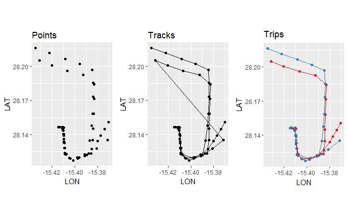

Here we transform the point representation into a trajectory representation as explained before. Very importantly we calculate the duration of each segment on the trajectory as well as the average speed and bearing.

```r
Points2Trajectory <- function(df){
  df <- df %>% arrange(TIMESTAMP)
  idx1 <- seq(1, nrow(df) - 1, 1)
  idx2 <- seq(2, nrow(df), 1)
  startpoints <- slice(df,idx1) %>% select(START_LON = LON, START_LAT = LAT)
  endpoints <- slice(df,idx2) %>% select(END_LON = LON, END_LAT = LAT)
  start_time <- slice(df,idx1) %>% .$TIMESTAMP
  end_time <- slice(df,idx2) %>% .$TIMESTAMP
  data.frame(slice(df,idx1) %>% select(MMSI),
             slice(df,idx1) %>% select(START_POSID = POSID),
             slice(df,idx2) %>% select(END_POSID = POSID),
             TIME_START = start_time,
             TIME_END = end_time,
             startpoints,
             endpoints,
             DISTANCE = distCosine(startpoints, endpoints),
             BEARING = bearing(startpoints, endpoints),
             TIME_DIFF = as.numeric(end_time - start_time, units = "secs")
             ) %>%
  mutate(AVG_SPEED = DISTANCE / TIME_DIFF,
         TIME_DIFF_MIN = round((TIME_DIFF/60)))
}
trajectories <- aisdata %>% group_by(MMSI) %>%
  do(Points2Trajectory(.)) %>% as.data.frame()
head(trajectories)
```

|  | MMSI | START_POSID | END_POSID | TIME_START | TIME_END | START_LON | START_LAT | END_LON | END_LAT | DISTANCE | BEARING | TIME_DIFF | AVG_SPEED | TIME_DIFF_MIN |
| --- | --- | --- | --- | --- | --- | --- | --- | --- | --- | --- | --- | --- | --- | --- |
| 1 | 203048100 | 1 | 2 | 2014-06-24 20:06:00 | 2014-06-24 20:53:00 | -15.42325 | 28.12765 | -15.42616 | 28.13070 | 443.721635 | -40.22443 | 2820 | 0.1573480976 | 47 |
| 2 | 203048100 | 2 | 3 | 2014-06-24 20:53:00 | 2014-06-24 22:05:00 | -15.42616 | 28.13070 | -15.42618 | 28.13068 | 2.967674 | -138.44311 | 4320 | 0.0006869617 | 72 |
| 3 | 203048100 | 3 | 4 | 2014-06-24 22:05:00 | 2014-06-24 22:41:00 | -15.42618 | 28.13068 | -15.42607 | 28.13067 | 10.855986 | 95.85511 | 2160 | 0.0050259196 | 36 |
| 4 | 203048100 | 4 | 5 | 2014-06-24 22:41:00 | 2014-06-25 00:29:00 | -15.42607 | 28.13067 | -15.42614 | 28.13068 | 6.961436 | -80.84559 | 6480 | 0.0010742956 | 108 |
| 5 | 203048100 | 5 | 6 | 2014-06-25 00:29:00 | 2014-06-25 00:47:00 | -15.42614 | 28.13068 | -15.42620 | 28.13064 | 7.383947 | -126.94402 | 1080 | 0.0068369880 | 18 |
| 6 | 203048100 | 6 | 7 | 2014-06-25 00:47:00 | 2014-06-25 01:35:00 | -15.42620 | 28.13064 | -15.42610 | 28.13069 | 11.284770 | 60.57620 | 2880 | 0.0039183229 | 48 |

#### Detect trips

We divide each vessel’s trajectory into a collection of trips. We do this based on the time difference between subsequent location measurements. In other words, if the time difference between two measurements exceeds a certain value, then it is assumed that the current vessel’s trip has ended and a new trip has started. This may be the case when a vessel either leaves the port area or turns off its AIS transmitter.

But first we must determine the time threshold above which a trajectory needs to be split or not. We do this by plotting the proportion of time differences observed between each measurement using a subselection of the data.

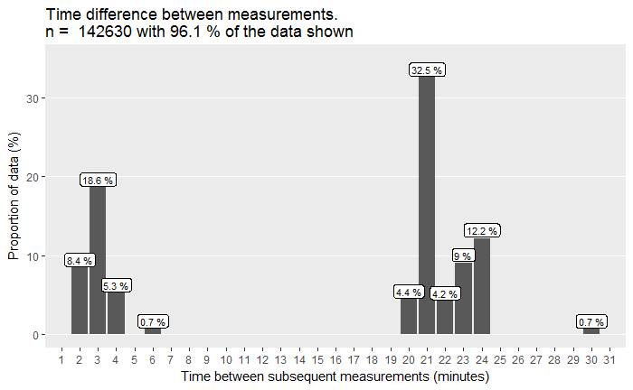

The plot above shows in what time intervals the vessels position measurements are updated as well as the proportion of measurements occurring at a given time interval. For instance we can see that 32.5% of the measurements occur in 21 minute intervals. Overall for 96.1% of the sampled data less than 30 minutes pass between subsequent measurements. *Footnote: Note that sampling rates that occur in less than 0.5% of the sampled data were excluded.*

We can see that the most frequent time intervals are concentrated within a small range of values. In other words most position measurement occur within 2 minutes and 4 minutes or within 20 minutes and 24 minutes.

Importantly, 63% of measurements occur within a 20 to 24 minute interval. This is in stark contrast to the nominal AIS reporting intervals which typically are either every 3 minutes or every 10 minutes. (Source: http://arundale.com/docs/ais/ais_reporting_rates.html). A possible reason for this could be that the data provided by Greenpeace had been sampled down to include fewer updates.

There are two takeaways from this. First, we set the time treshold to determine where to split the trajectory into separate trips at 30 minutes. Second, the rather long measurement intervals determine the machine learning methods that can realistically be used for classifying vessels based on their navigation data. For instance methods relying on the geometric properties of a trajectory may be less suitable because sparse measurements also mean that the geometry of a vessel will not be very well described.

Next we split the trajectory data into separate trips according to the 30 minute time threshold we have just determined. For this we have written a function `Trajectory2Trips()` which does this for us.

```r
Trajectory2Trips <- function(df){
  # TODO SORT BY TIME
  result <- c(1:nrow(df))
  # 30 Minute time threshold determined before in seconds
  threshold <- 30*60
  counter <- 1
  for (i in 1:nrow(df)) {
    if (df$TIME_DIFF[i] <= threshold){
      result[i] <- counter
    }else{
      result[i] <- -1
      counter <- counter + 1
    }
  }
  data.frame(result)
}
```

We apply the `Trajectory2Trips()` function to the dataframe and save the result in a new dataframe `trips`. Now that the data is in the correct format we can carry out some exploratory data analysis.

```r
# Convert trajectories into trips
trips <- trajectories %>%
  group_by(MMSI) %>% # TODO THIS PROBABLY NEEDS TO STAY ON BUT WAS OFF UNTIL 30.05
  do(Trajectory2Trips(.)) %>%
  as.data.frame() %>%
  select(result) %>%
  cbind(trajectories)
colnames(trips)[1] <- "TRIP_ID"
# Remove invalid trips (where there is a large time gap)
trips <- filter(trips, TRIP_ID > -1)
# Create unique ids for each Trip-MMSI combination
tmp <- trips[c("TRIP_ID", "MMSI")] %>% distinct()
tmp <- mutate(tmp, TRIP_ID_NEW = seq(1:nrow(tmp)))
trips <- left_join(trips, tmp, by=c('TRIP_ID', 'MMSI'))
trips$TRIP_ID <- trips$TRIP_ID_NEW
trips <- subset(trips, select = -c(TRIP_ID_NEW))
# Only keep trips with at least 5 segments.
tmp_to_keep <- trips %>% count(TRIP_ID) %>% filter(n > 5) %>% .$TRIP_ID
trips <- filter(trips, TRIP_ID  %in% tmp_to_keep)
rm(tmp_to_keep, tmp)
```

#### Recoding vessel categories

As explained in the introduction a curated list of vesseltypes was used instead of the crude vessel categorisation provided by the AIS devices themselves. Furthermore the categorisation was further refined by recoding some of the categories.

```r
vesseldetails$VESSEL_TYPE <- recode(vesseldetails$ship.type,
                                   "Sailing Vessel" = "Pleasure Craft",
                                   "Passengers Ship" = "Passenger",
                                   "Ro-Ro/Passenger Ship" = "Passenger",
                                   "Ro-Ro Cargo" = "Passenger",
                                   "Crude Oil Tanker" = "Tanker",
                                   "Oil Products Tanker" = "Tanker",
                                   "Chemical Tanker" = "Tanker",
                                   "Oil/Chemical Tanker" = "Tanker",
                                   "LPG Tanker" = "Tanker",
                                   "Fishing" = "Fishing Vessel")
# Let's also add the vessel.type column to the trips dataframe.
trips <- left_join(trips, vesseldetails[,c('MMSI', 'VESSEL_TYPE')], by = 'MMSI')
trips$VESSEL_TYPE <- as.factor(trips$VESSEL_TYPE)
head(trips)
```

|  | TRIP_ID | MMSI | START_POSID | END_POSID | TIME_START | TIME_END | START_LON | START_LAT | END_LON | END_LAT | DISTANCE | BEARING | TIME_DIFF | AVG_SPEED | TIME_DIFF_MIN | VESSEL_TYPE |
| --- | --- | --- | --- | --- | --- | --- | --- | --- | --- | --- | --- | --- | --- | --- | --- | --- |
| 1 | 2 | 203048100 | 11 | 12 | 2014-06-25 10:31:00 | 2014-06-25 10:34:00 | -15.42253 | 28.12921 | -15.42034 | 28.12743 | 292.3807 | 132.51503 | 180 | 1.624337 | 3 | Pleasure Craft |
| 2 | 2 | 203048100 | 12 | 13 | 2014-06-25 10:34:00 | 2014-06-25 10:37:00 | -15.42034 | 28.12743 | -15.41702 | 28.12501 | 422.8568 | 129.42655 | 180 | 2.349204 | 3 | Pleasure Craft |
| 3 | 2 | 203048100 | 13 | 14 | 2014-06-25 10:37:00 | 2014-06-25 10:42:00 | -15.41702 | 28.12501 | -15.41148 | 28.12142 | 674.9337 | 126.16296 | 300 | 2.249779 | 5 | Pleasure Craft |
| 4 | 2 | 203048100 | 14 | 15 | 2014-06-25 10:42:00 | 2014-06-25 10:44:00 | -15.41148 | 28.12142 | -15.40773 | 28.12045 | 383.6783 | 106.26417 | 120 | 3.197319 | 2 | Pleasure Craft |
| 5 | 2 | 203048100 | 15 | 16 | 2014-06-25 10:44:00 | 2014-06-25 10:46:00 | -15.40773 | 28.12045 | -15.40431 | 28.11973 | 345.2075 | 103.35711 | 120 | 2.876729 | 2 | Pleasure Craft |
| 6 | 2 | 203048100 | 16 | 17 | 2014-06-25 10:46:00 | 2014-06-25 10:48:00 | -15.40431 | 28.11973 | -15.40116 | 28.12068 | 326.8467 | 71.21261 | 120 | 2.723722 | 2 | Pleasure Craft |

### Feature Engineering

Vessel trajectories are not just some geometric shapes existing in a vacuum. First, they have specific properties relating to the vessel creating the trajectory. For instance the speed of the vessel across the trajectory or the time of travel.

Second, they exist in spaces with their own semantics. For instance vessels often travel along sea lanes and they dock in harbours or specific docking areas. Because different type of vessels often dock at different locations within a port and travel on different sea leanes such information is particularly helpful within a vessel classification setting. Indeed previous research has shown that adding domain knowledge to trajectory data can significantly increase classification accuracy (Vries, 2012, p.87).

In this section I describe the feature engineering steps I undertook in order to add domain knowledge to the trajectories and to extract intrinsic trajectory-properties from the data.

#### Adding domain knowledge

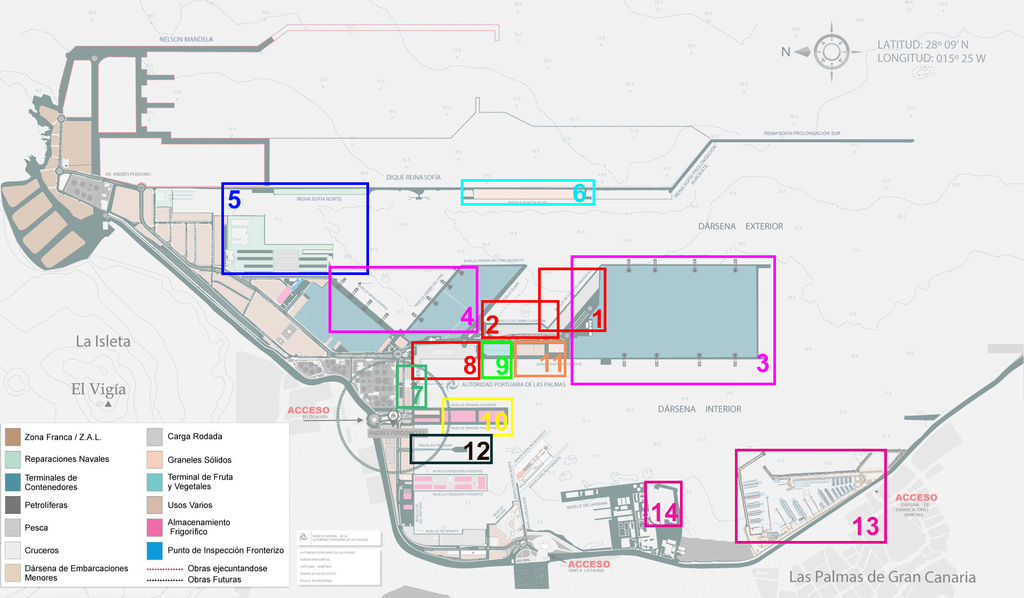

Port areas (overlapping areas were resolved using set operations.)

The boundaries and their geographic coordinates were defined in a spreadsheet and subsequently imported into R. Overlapping areas (e.g. area 1 and area 3) were corrected using set operations. For each segment in the previously generated `trips` dataframe we check if the segment is within in any of the defined port areas. We record the results in a sparse matrix [#segments x #areas] and export the data.

```r
# Note this code is very slow (run time ~5 minutes), do not run but rather load
# the the sparse matrix in the next block. TODO: rewrite using for loop.
tmp_positions <-  c('START_LON', 'START_LAT', 'END_LON', 'END_LAT')
areas = read_csv('./dataset/in/areas.csv')
locmat_sparse <- apply(trips[tmp_positions],1, function(x){
  tmp_vec <- rep(0, nrow(areas))
  indeces <- intersect(filter(areas, lon_left <= x['START_LON'],
                              x['START_LON'] <= lon_right,
                              lat_bottom <= x['START_LAT'],
                              x['START_LAT'] <= lat_top) %>% .$area_code,
                       filter(areas, lon_left <= x['END_LON'],
                              x['END_LON'] <= lon_right,
                              lat_bottom <= x['END_LAT'],
                              x['END_LAT'] <= lat_top) %>% .$area_code)
  tmp_vec[indeces] <- 1
  tmp_vec
  }) %>% t %>% Matrix(locmat, sparse = TRUE)

# Fix area 3 which overlaps area 1. (avoid double counting)
locmat_sparse[,3] <- (locmat_sparse[,3] - locmat_sparse[,1])
locmat_sparse[locmat_sparse[,3] == -1,3] <- 0
writeMM(locmat_sparse, file = './dataset/in/locmat_sparse.txt')
rm(tmp_positions)
```

Once we know which segments of a vessels trips are in which area we can compute for each vessel, for each trip the total time spent in the respective areas defined.

```r
# Load areas and locmat again (previous codeblock is usually not run).
areas <- read_csv('./dataset/in/areas.csv')
locmat_sparse <- readMM(file = './dataset/in/locmat_sparse.txt')
# For each trip compute time spent in each area, return list of df. TODO: change
# into for loop.
time_in_area_list <- apply(locmat_sparse, 2, function(x)
  trips %>%
    select(TRIP_ID, MMSI, TIME_DIFF, START_POSID) %>%
    slice(which(x != 0)) %>%  # TODO IF I COMMENT THIS OUT IT FIXES MISSING IDS ISSUE
    group_by(TRIP_ID) %>%
    summarise(total_time = sum(TIME_DIFF)) %>%
    data.frame())
# In the previous list of df rename the total_time column.
time_in_area_list <- lapply(seq_along(time_in_area_list), function(x){
  df <- data.frame(time_in_area_list[x])
  names(df)[-1] <- paste('area',x,sep = '_')
  df
})
# Join all those list together to get 1df with total time spent in each area.
time_in_area <- time_in_area_list %>%
  Reduce(function(df1,df2) full_join(df1, df2, by = "TRIP_ID"), .) %>%
  arrange(TRIP_ID)
time_in_area <- left_join(time_in_area, distinct(trips[c('TRIP_ID')]),
                          by='TRIP_ID')
time_in_area_long <- gather(time_in_area, statistic, value, area_1:area_15,
                            factor_key=TRUE) %>%
  filter(value>= 0) %>%
  left_join(distinct(trips[c("TRIP_ID", "MMSI", "VESSEL_TYPE")]), by="TRIP_ID")

rm(time_in_area_list)
```

It is also useful to know which segments of a vessel’s trips are outside the port area and which ones are inside. For instance when comparing the average speed across different types of vessels it makes sense to do this only on those parts of a trajectory that are outside the port area. The reason bein that within the port areas all vessel are required to abide to speed limits and therefore navigate at similar speeds. In contrast on open water vessels are allowed to navigate at their full speed and consequently allow us to discriminate between high speed vessels and slow sailing vessels just to mention a few. For this purpose we create a new binomial feature in `trips` indicating which segments are within the port area and which outside.

```r
trips <- mutate(trips, IN_PORT = as.factor(locmat_sparse[,15]))
levels(trips$IN_PORT) <- c("Outside Port", "In Port")
```

#### Computing trip statistics

```r
trips_stats <- group_by(trips, TRIP_ID, MMSI, VESSEL_TYPE) %>%
  summarize(duration_total_minutes = sum(TIME_DIFF)/60,
            duration_segment = mean(TIME_DIFF),
            speed_avg = mean(AVG_SPEED),
            speed_max = max(AVG_SPEED),
            distance_total = sum(DISTANCE),
            distance_segment = mean(DISTANCE),
            time_start = min(TIME_START),
            time_end = max(TIME_END)) %>%
  ungroup() %>%
  left_join(x=., y = time_in_area, by = "TRIP_ID")
trips_stats[is.na(trips_stats)] <- 0
```

### Exploratory Analysis

In this section we carry out the exploratory data analysis. The goal is on the one hand to get a better feel of the data, to answer some preliminary but nonetheless important question and to inform the feature engineering process.

#### Which vessel types carry out the greatest number of trips?

Since the purpose of this research is to classify vessels we first need to find out for which type of vessels there is enough data to work with. To do that we count the number of unique trips per vessel-type.

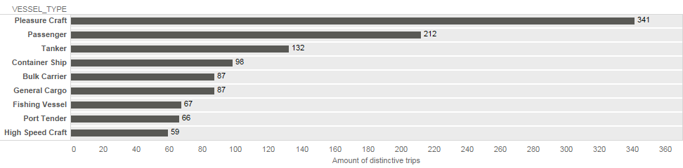

#### Do vessels travel at different speeds?

Here we investigate whether different types of vessels navigate at different speeds. To do this we check the navigation speed distribution per vesseltype. We consider a ship to be navigating when it’s travellspeed exceeds a thresholdvalue of 1m/s. We do this for the trips taking place inside as well as outside the port of Las Palmas. We make this distinction because we hypothesize that inside the port vessels will either travel at similar speeds prescribed by the port authorities or they will be docked.

Overall these plots suggest that the navigatin speed may be a good feature to individuate high speed vessels but it is less of a good feature to for instance distinguish between bulk carriers and container vessels where there is much overlap.

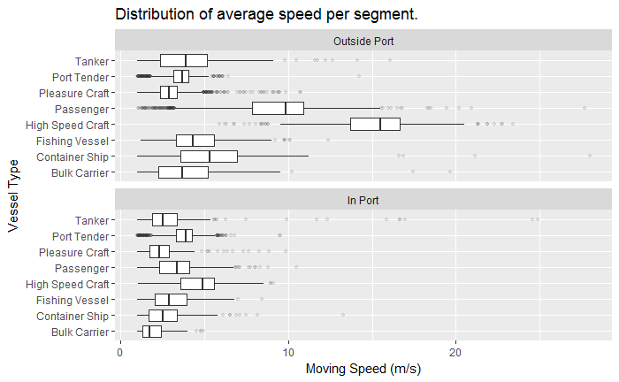

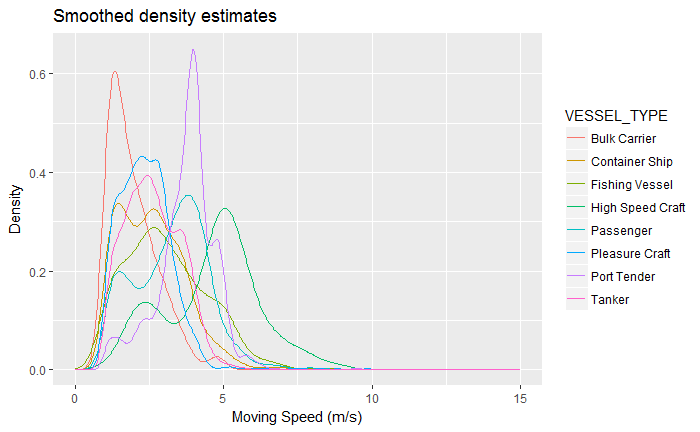

#### Which vessels spent how much time in each area?

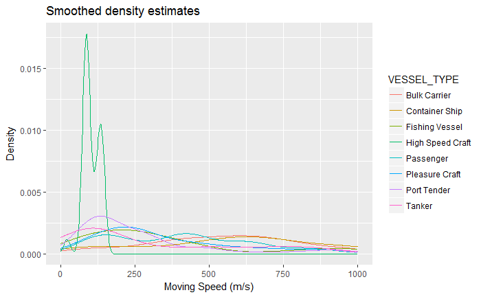

```r
# plot_tripduration_box <- filter(trips_stats, VESSEL_TYPE %in% categories) %>%
#   ggplot() +
#   geom_boxplot(mapping = aes(x = VESSEL_TYPE, y = duration_total_minutes),
#                outlier.alpha = 0.1, outlier.size = 1) +
#   labs(title = 'Distribution of average speed per segment.',
#        x = 'Vessel Type', y = 'Moving Speed (m/s)') +
#   coord_flip()
# plot_tripduration_box
trips_stats %>%
  filter(VESSEL_TYPE %in% categories) %>%
  ggplot() +
  geom_freqpoly(mapping = aes(x = duration_total_minutes, color=VESSEL_TYPE),
                stat = 'density') +
  labs(title = 'Smoothed density estimates', x = 'Moving Speed (m/s)', y = 'Density') +
  xlim(0,1000)
```

# Export all data

**Average Trip Duration**

```r
# Check how many datapoints are outside port
# **Average Speed/Max/Min**
```